# Analyzing the Disaster of the Titanic:

### By: Matthew Hou

## Background

On April 14, 1912 the sinking of the RMS Titanic was a horrific event that included the deaths of over 1500 people when crashing into an iceburg during its voyage from Southampton to New York City. Through this tragic event, I would like to analyze the data about the passengers on board the Titanic to create a model that can help to predict the likelyhood of a person surviving another catastrophic event like this. If you would like to read more about the sinking of the Titanic, there is a nice write-up in Wikipedia at: https://en.wikipedia.org/wiki/RMS_Titanic

In a more data science prospective, we will be going through how to import a dataset with pandas, analyze data within the data set through basic manipulations, visualizing our analysis through plotting with mathplotlib, as well as being able to interpret all this and putting it all together. After doing this, we will be able to understand more about the statistical data on the Titanic and perhaps learn from this tragic experience.

## PART 0 - SETTING UP

## Step 1: Downloading the Datasets

Lets begin by Downloading the Data set which can be found on the following link: (You may need to log in via Facebook or Google to download the entire dataset) https://www.kaggle.com/c/titanic/data

[figure not shown]

*As you can see, Kaggle provides a small preview of what the dataset looks like here as well as a description of what the dataset is about.*

## Step 2: Understanding the Datasets

Before we can analyze this data, we must first understand our data. We can read through this description to understand what is contained in these files in order to move forward:

### Overview

The data has been split into two groups: training set (train.csv) test set (test.csv) The training set should be used to build your machine learning models. For the training set, we provide the outcome (also known as the “ground truth”) for each passenger. Your model will be based on “features” like passengers’ gender and class. You can also use feature engineering to create new features. The test set should be used to see how well your model performs on unseen data. For the test set, we do not provide the ground truth for each passenger. It is your job to predict these outcomes. For each passenger in the test set, use the model you trained to predict whether or not they survived the sinking of the Titanic. We also include gender_submission.csv, a set of predictions that assume all and only female passengers survive, as an example of what a submission file should look like.

### Data Dictionary

[figure not shown]

*age: Age is fractional if less than 1. If the age is estimated, is it in the form of xx.5*

*sibsp: The dataset defines family relations in this way... Sibling = brother, sister, stepbrother, stepsister Spouse = husband, wife (mistresses and fiancés were ignored)*

*parch: The dataset defines family relations in this way... Parent = mother, father Child = daughter, son, stepdaughter, stepson Some children travelled only with a nanny, therefore parch=0 for them.*

## Step 3: Setting up your Jupyter Notebook (for Python) and Python Libraries

Now that we have our data and understand what the data is, we can begin to set up our coding environment with the Jupyter Notebook and importing some Python libraries that will help us to accomplish our analysis a bit easier.

For installing Jupyter Notebook visit here: https://jupyter.readthedocs.io/en/latest/install.html

### The libraries we will be using:

```
Pandas
Sklearn
Numpy
MatlibPlot
```

## Step 4: Importing Python Libraries

Now that we have everything that we need, we can begin by including the libraries we will be needing to do our analysis. (You might get a warning like the one below, but we do not need to worry about this because we are not even using umath)

```python
import pandas as pd
import sklearn
import numpy as np
import matplotlib.pyplot as plt
from sklearn.linear_model import LinearRegression
from sklearn.ensemble import RandomForestRegressor
```

```
/Users/matthou/anaconda3/lib/python3.6/site-packages/sklearn/ensemble/weight_boosting.py:29: DeprecationWarning: numpy.core.umath_tests is an internal NumPy module and should not be imported. It will be removed in a future NumPy release.
  from numpy.core.umath_tests import inner1d
```

## Step 5: Preview the Data

After we have imported the libraries, we can begin loading our datasets into a Pandas Dataframe. Here we are just using the head function to print out the first five rows of the dataframe to get an idea of what our data looks like.

```python
training_data = pd.read_csv('train.csv')
training_data.head(5)
```

|  | PassengerId | Survived | Pclass | Name | Sex | Age | SibSp | Parch | Ticket | Fare | Cabin | Embarked |
| --- | --- | --- | --- | --- | --- | --- | --- | --- | --- | --- | --- | --- |
| 0 | 1 | 0 | 3 | Braund, Mr. Owen Harris | male | 22.0 | 1 | 0 | A/5 21171 | 7.2500 | NaN | S |
| 1 | 2 | 1 | 1 | Cumings, Mrs. John Bradley (Florence Briggs Th... | female | 38.0 | 1 | 0 | PC 17599 | 71.2833 | C85 | C |
| 2 | 3 | 1 | 3 | Heikkinen, Miss. Laina | female | 26.0 | 0 | 0 | STON/O2. 3101282 | 7.9250 | NaN | S |
| 3 | 4 | 1 | 1 | Futrelle, Mrs. Jacques Heath (Lily May Peel) | female | 35.0 | 1 | 0 | 113803 | 53.1000 | C123 | S |
| 4 | 5 | 0 | 3 | Allen, Mr. William Henry | male | 35.0 | 0 | 0 | 373450 | 8.0500 | NaN | S |

## PART 1 - GETTING OUR FEET WET

## Step 1: Lets take a look at what we got!

Before doing anything crazy, lets first look at what we have to look at. We can do this by visualizing our data by creating plots through Matplotlib.

## Lets plot two basic histograms to get ourselves warmed up!

### The Distribution of Fares the Passengers Paid

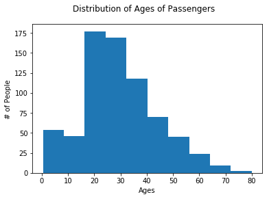

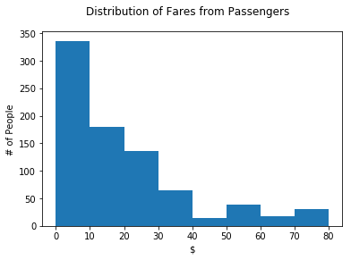

[output not shown]

```python
ages = []
fares = []
for i in range(len(training_data)):
    if not(np.isnan(training_data['Age'].values[i])):
        ages.append(training_data['Age'].values[i])
    if not(np.isnan(training_data['Fare'].values[i])):
        fares.append(training_data['Fare'].values[i])
fig = plt.figure()
plt.xlabel('Ages')
plt.ylabel('# of People')
fig.suptitle('Distribution of Ages of Passengers')
plt.hist(ages)
plt.show()

fig = plt.figure()
plt.xlabel('$')
plt.ylabel('# of People')
fig.suptitle('Distribution of Fares from Passengers')
plt.hist(fares, bins = [0, 10, 20, 30, 40, 50, 60, 70, 80])
plt.show()
print ('***Those who paid more than $80 are lumped into the $70-$80 category***')
```

## Step 2: Our First Analysis - What percentage of the passengers on board survived?

Now that we have a Pandas Dataframe with all the data we need, we can begin to do some analysis on it. To figure out who survived and who did not survive, we need to keep a total tally of both the survivors and the deceased. Then we can divide both of those by the total passengers x100 to get a percentage.

```
# of people who survived: 342
# of people who died: 549
Total # of people: 891


Percentage of people who survived: 38.38383838383838%
Percentage of people who died: 61.61616161616161%
```

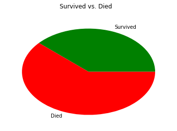

```python
survived = 0
died = 0
total = len(training_data)
for i in range (len (training_data)):
    if training_data['Survived'].values[i] == 0:
        died += 1
    else:
        survived += 1
print ('# of people who survived: ' + str(survived))
print ('# of people who died: ' + str(died))
print ('Total # of people: ' + str(total))
print ('\n\nPercentage of people who survived: ' + str((survived/total)*100) + '%')
print ('Percentage of people who died: ' + str((died/total)*100) + '%')
fig = plt.figure()
fig.suptitle('Survived vs. Died')
plt.pie([survived, died], labels = ['Survived', 'Died'], colors = ['green', 'red'])
plt.show()
```

## Step 3: Diving a bit Deeper - What percentage of people who survived are men vs. women?

Now that we have some basic information, we can dive in a bit deeper on the situation and look at which sex had a higher rate of survival, men or women?

After some calculation, we can see here that about 109 or 31.87% of the passengers who survived where men and roughly 233 or 68.13% of the passengers who survived where women. Based on these numbers, we can see that mostly women are the ones who survived this catastrophic event.

```
# of men who survived: 109
# of women who survived: 233


Percentage of people who survived (men): 31.871345029239766%
Percentage of people who died: 68.12865497076024%
```

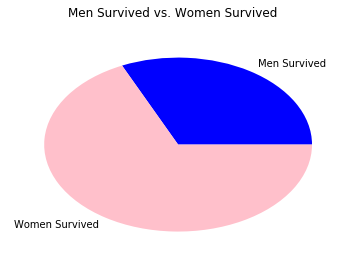

```python
men_survived = 0
women_survived = 0
for i in range (len (training_data)):
    if (training_data['Survived'].values[i] == 1) and ((training_data['Sex'].values[i] == 'male') or training_data['Sex'].values[i] == 1):
        men_survived += 1
    elif (training_data['Survived'].values[i] == 1) and ((training_data['Sex'].values[i] == 'female') or training_data['Sex'].values[i] == 0):
        women_survived += 1
print ('# of men who survived: ' + str(men_survived))
print ('# of women who survived: ' + str(women_survived))

print ('\n\nPercentage of people who survived (men): ' + str((men_survived/survived)*100) + '%')
print ('Percentage of people who died: ' + str((women_survived/survived)*100) + '%')

fig = plt.figure()
fig.suptitle('Men Survived vs. Women Survived')
plt.pie([men_survived, women_survived], labels = ['Men Survived', 'Women Survived'], colors = ['blue', 'pink'])
plt.show()
```

## PART 2 - LET'S CREATE OUR FIRST LINEAR REGRESSION MODEL!

Now that we got a feel for how to do some basic analysis of the data that we have, lets raise the stakes a bit. Now we want to be able to predict whether or not a person would have survived the titanic through linear regression with multiple variables.

## Step 1: Identifying which attributes the data that contributes to survival

In order to run linear regression on our data set, we must decide what kind of data matters the most. This is important because if we were to just include all of our data, then our linear regression model might think there are correlations that might not actually exist. Below lets analyze each column to decide what we want to use:

#### PassengerId - No

-Just because your passenger ID is higher or lower does not mean you have a higher chance of surviving necessarily, so we can exclude this from our list of columns to use.

#### Survived - Yes, but is our target

-This will ultimately be our target that we want our linear regression to replicate.

#### Pclass - Yes

-This has to do with the general wealth of the passenger which could matter because maybe those who are in a higher class will get treated first.

#### Name - No

-Just because your name is "Bob" vs. "Brian" should not affect whether or not you survive so we will not include this column.

#### Sex - Yes

-As we saw earlier, more females than males have survived so the sex of a person could impact their chance of survival so we should include this as part of our linear regression.

#### Age - Yes

-This could affect our chances of survival because generally elderly people are not as strong as those who may be in there mid 20's, so lets include this column.

#### SibSp - Yes

-This has to do with the number of siblings the individual has onboard. We will just include this since perhaps if someone has siblings they may be more likely to survive because there is support nearby

#### Parch - Yes

-This has to do with the number of parents/gaurdians of this individual on board. We will include this for the same reason as SibSp

#### Ticket - No

-This column just tells us what the ticket number is, which should not affect whether or not you survive (similar to the PassengerId).

#### Fare - Yes

-Knowing how much a person paid relates to what class a person is.

```python
print ("A list of the columns we have:")
for i in range (len(training_data.columns)):
    print (training_data.columns[i])
```

```
A list of the columns we have:
PassengerId
Survived
Pclass
Name
Sex
Age
SibSp
Parch
Ticket
Fare
Cabin
Embarked
```

## Step 2: Tailoring Our Training Data to be Useable

Now that we have identified which columns we would like to use in our linear regression, we need to make sure our data is clean before building our new training data to use.

### Step 2a: One-Hot-Key encoding

For the sex of the passengers, we need the computer to be able to understand the distinction between male and female by a value to male and female. In our case, we can use 1 for male and 0 for female. After applying One-Hot-Key encoding we can see that our new dataFrame now has 1's and 0's for the Sex column.

```python
for i in range (len(training_data)):
    if (training_data['Sex'].values[i] == 'male' or training_data['Sex'].values[i] == 1):
        training_data['Sex'].values[i] = 1
    else:
        training_data['Sex'].values[i] = 0
training_data.head(5)
```

|  | PassengerId | Survived | Pclass | Name | Sex | Age | SibSp | Parch | Ticket | Fare | Cabin | Embarked |
| --- | --- | --- | --- | --- | --- | --- | --- | --- | --- | --- | --- | --- |
| 0 | 1 | 0 | 3 | Braund, Mr. Owen Harris | 1 | 22.0 | 1 | 0 | A/5 21171 | 7.2500 | NaN | S |
| 1 | 2 | 1 | 1 | Cumings, Mrs. John Bradley (Florence Briggs Th... | 0 | 38.0 | 1 | 0 | PC 17599 | 71.2833 | C85 | C |
| 2 | 3 | 1 | 3 | Heikkinen, Miss. Laina | 0 | 26.0 | 0 | 0 | STON/O2. 3101282 | 7.9250 | NaN | S |
| 3 | 4 | 1 | 1 | Futrelle, Mrs. Jacques Heath (Lily May Peel) | 0 | 35.0 | 1 | 0 | 113803 | 53.1000 | C123 | S |
| 4 | 5 | 0 | 3 | Allen, Mr. William Henry | 1 | 35.0 | 0 | 0 | 373450 | 8.0500 | NaN | S |

### Step 2b: Checking for NaN in our data

There are many different ways to handle when there is a NaN in the data, but for simplicity, lets just have a set to keep track of the indexes that have a NaN so we know not to use these indexes when building our new training data. (Here we can print out our nan_indexes to see what it looks like)

```python
nan_indexes = set()
for i in range (len(training_data)):
    x = training_data
    if (np.isnan(x['Pclass'].values[i]) or
        pd.isnull(x['Sex'].values[i]) or
        np.isnan(x['Age'].values[i]) or
        np.isnan(x['SibSp'].values[i]) or
        np.isnan(x['Parch'].values[i]) or
        np.isnan(x['Fare'].values[i])):
        nan_indexes.add(i)
print (nan_indexes)
```

[output not shown]

## Step 3: Building our new training data and target data

Now that we have cleaned up our data a bit, lets build our training data and target data. The training data will contain all the columns that we discussed previously and our target data will contain whether or not the particular person has survived or not.

```python
n_train = []
n_target = []
for i in range (len(training_data)):
    if i not in nan_indexes:
        x = training_data
        n_train.append([x['Pclass'].values[i],
                        x['Sex'].values[i],
                        x['Age'].values[i],
                        x['SibSp'].values[i],
                        x['Parch'].values[i],
                        x['Fare'].values[i]])
        n_target.append(x['Survived'].values[i])
```

## Step 4: Creating our Linear Regression Model and Testing it

Now that our n_train has our training data and n_target has our expected results, we can go ahead and set up our linear regression model and fit the model to our data.

Once we have our model fitted, we can have a little fun here and see how accurately our model could predict on our training set by calling predict on our n_train with our model. After that we can see how our model can achieve nearly 80% accuracy.

```python
model1 = LinearRegression()
model1.fit(n_train, n_target)
predictions = model1.predict(n_train)
residuals = []
correct = 0

for i in range (len(predictions)):
    if predictions[i] > 0.5:
        predictions[i] = 1
    else:
        predictions[i] = 0
    residuals.append(n_target[i] - predictions[i])
    if (n_target[i] - predictions[i] == 0):
        correct +=1
print ('Accuracy of Training Set: ' + str(correct*100/len(residuals)) + '%')
```

```
Accuracy of Training Set: 79.69187675070027%
```

### Step 4a: Playing around with our Linear Regession Model

If you are a curious person and wanted to see whether the model believes a person would survive or not, we can create our own entries and feed it through the model.

For example, lets compare what the model thinks the chance of survival would be for a rich person (class 1, \$99 fare) vs. a poor person (class 3, \$7 fare). Lets also do a little comparison for age, comparing a young person (18 years old) to an old person (87 years old) and see the differences.

```python
rich_person = [1, 0, 28, 1, 1, 99]
poor_person = [3, 0, 28, 1, 1, 7]
old_person = [2, 0, 87, 1, 1, 20]
young_person = [2, 0, 18, 1, 1, 20]
fun_predictions = model1.predict([rich_person, poor_person, young_person, old_person])
print ('Predicted chance of survival for a rich person: ' + str(fun_predictions[0]*100) + "%.")
print ('Predicted chance of survival for a poor person: ' + str(fun_predictions[1]*100) + "%.")
print ('Predicted chance of survival for a young person: ' + str(fun_predictions[2]*100) + "%.")
print ('Predicted chance of survival for a old person: ' + str(fun_predictions[3]*100) + "%.")
```

```
Predicted chance of survival for a rich person: 95.38637332658195%.
Predicted chance of survival for a poor person: 53.77423252189032%.
Predicted chance of survival for a young person: 80.09405257999595%.
Predicted chance of survival for a old person: 35.05489036190623%.
```

## Step 5: Testing Our Model on New Data

In order to test our data, we essentially need to repeat the steps done previously, making sure to do One-Hot-Key encoding on Sex, as well as checking for NaN values. Next, we have to build our test input data as well as our test targets (test_input and tets_target respectively).

```python
#Loading the Test Dataset
testing_data = pd.read_csv('test.csv')
testing_target = pd.read_csv('gender_submission.csv')

#One-Hot-Key Encoding
for i in range (len(testing_data)):
    if (testing_data['Sex'].values[i] == 'male' or testing_data['Sex'].values[i] == 1):
        testing_data['Sex'].values[i] = 1
    else:
        testing_data['Sex'].values[i] = 0

#Checking for NaNs
nan_indexes_t = set()
for i in range (len(testing_data)):
    x = testing_data
    if (np.isnan(x['Pclass'].values[i]) or
        pd.isnull(x['Sex'].values[i]) or
        np.isnan(x['Age'].values[i]) or
        np.isnan(x['SibSp'].values[i]) or
        np.isnan(x['Parch'].values[i]) or
        np.isnan(x['Fare'].values[i])):
        nan_indexes_t.add(i)

#Setting up the Testing Inputs and expected results
test_input = []
test_target = []
for i in range (len(testing_data)):
    if i not in nan_indexes_t:
        x = testing_data
        test_input.append([x['Pclass'].values[i],
                        x['Sex'].values[i],
                        x['Age'].values[i],
                        x['SibSp'].values[i],
                        x['Parch'].values[i],
                        x['Fare'].values[i]])
        test_target.append(testing_target['Survived'].values[i])

#Obtaining the accuracy of the test set
residuals_t = []
correct_t = 0
test_predictions = model1.predict(test_input)
for i in range (len(test_predictions)):
    if test_predictions[i] >= 0.5:
        test_predictions[i] = 1
    else:
        test_predictions[i] = 0
    residuals_t.append(test_target[i] - test_predictions[i])
    if (test_target[i] - test_predictions[i] == 0):
        correct_t +=1
print ('Accuracy of Test Set: ' + str(correct_t*100/len(residuals_t)) + '%')
```

```
Accuracy of Test Set: 95.46827794561933%
```

## PART 3 - PLAYING AROUND WITH A DIFFERENT MODEL: RANDOM FOREST REGRESSION

After looking through our linear regression model, lets explore the other models that sklearn have to offer. Another one we can look at is the random forest regressor. Unlike the linear regression model, this model will have a bit of randomness so what we can do is run the model several times to see how the model performs in each of the random states. In this case, lets suppose we ran our model 10 times.

Due to its random nature, we can see here that there is some variance between each of the rounds. We can especially see this when we make up our own test people (like we did previously).

```python
#This will run 10 times
for i in range (10):
    print ('Round ' + str(i+1))

    #Creating our Forest Model and fitting it with our training data
    forest_model = RandomForestRegressor()
    forest_model.fit(n_train, n_target)

    #Testing the accuracy on our training data
    forest_predictions = forest_model.predict(n_train)
    residuals_f = []
    correct_f = 0
    for i in range (len(forest_predictions)):
        if forest_predictions[i] >= 0.5:
            forest_predictions[i] = 1
        else:
            forest_predictions[i] = 0
        residuals_f.append(n_target[i] - forest_predictions[i])
        if (n_target[i] - forest_predictions[i] == 0):
            correct_f +=1
    print ('Accuracy of Train Set: ' + str(correct_f*100/len(residuals_f)) + '%')

    #Testing the accuracy on our testing data
    forest_predictions_t = forest_model.predict(test_input)
    residuals_f_t = []
    correct_f_t = 0
    for i in range (len(forest_predictions_t)):
        if forest_predictions_t[i] >= 0.5:
            forest_predictions_t[i] = 1
        else:
            forest_predictions_t[i] = 0
        residuals_f_t.append(test_target[i] - forest_predictions_t[i])
        if (test_target[i] - forest_predictions_t[i] == 0):
            correct_f_t +=1
    print ('Accuracy of Test Set: ' + str(correct_f_t*100/len(residuals_f_t)) + '%')

    #Lets use the same made up people as our linear regression to see how the forest model does
    rich_person = [1, 0, 28, 1, 1, 99]
    poor_person = [3, 0, 28, 1, 1, 7]
    old_person = [2, 0, 87, 1, 1, 20]
    young_person = [2, 0, 18, 1, 1, 20]
    fun_predictions = forest_model.predict([rich_person, poor_person, young_person, old_person])
    print ('Predicted chance of survival for a rich person: ' + str(fun_predictions[0]*100) + "%.")
    print ('Predicted chance of survival for a poor person: ' + str(fun_predictions[1]*100) + "%.")
    print ('Predicted chance of survival for a young person: ' + str(fun_predictions[2]*100) + "%.")
    print ('Predicted chance of survival for a old person: ' + str(fun_predictions[3]*100) + "%.\n")
```

```
Round 1
Accuracy of Train Set: 97.19887955182072%
Accuracy of Test Set: 80.06042296072508%
Predicted chance of survival for a rich person: 100.0%.
Predicted chance of survival for a poor person: 70.0%.
Predicted chance of survival for a young person: 100.0%.
Predicted chance of survival for a old person: 50.0%.

Round 2
Accuracy of Train Set: 96.77871148459384%
Accuracy of Test Set: 82.4773413897281%
Predicted chance of survival for a rich person: 100.0%.
Predicted chance of survival for a poor person: 80.0%.
Predicted chance of survival for a young person: 60.0%.
Predicted chance of survival for a old person: 70.0%.

Round 3
Accuracy of Train Set: 96.77871148459384%
Accuracy of Test Set: 78.24773413897282%
Predicted chance of survival for a rich person: 100.0%.
Predicted chance of survival for a poor person: 30.0%.
Predicted chance of survival for a young person: 80.0%.
Predicted chance of survival for a old person: 90.0%.

Round 4
Accuracy of Train Set: 97.19887955182072%
Accuracy of Test Set: 77.34138972809667%
Predicted chance of survival for a rich person: 100.0%.
Predicted chance of survival for a poor person: 70.0%.
Predicted chance of survival for a young person: 70.0%.
Predicted chance of survival for a old person: 50.0%.

Round 5
Accuracy of Train Set: 97.19887955182072%
Accuracy of Test Set: 78.24773413897282%
Predicted chance of survival for a rich person: 100.0%.
Predicted chance of survival for a poor person: 50.0%.
Predicted chance of survival for a young person: 100.0%.
Predicted chance of survival for a old person: 60.0%.

```

[output cut: 24 more lines]

```
Round 9
Accuracy of Train Set: 96.77871148459384%
Accuracy of Test Set: 80.96676737160121%
Predicted chance of survival for a rich person: 100.0%.
Predicted chance of survival for a poor person: 60.0%.
Predicted chance of survival for a young person: 70.0%.
Predicted chance of survival for a old person: 50.0%.

Round 10
Accuracy of Train Set: 97.61904761904762%
Accuracy of Test Set: 80.66465256797584%
Predicted chance of survival for a rich person: 100.0%.
Predicted chance of survival for a poor person: 30.0%.
Predicted chance of survival for a young person: 70.0%.
Predicted chance of survival for a old person: 50.0%.
```

## WHAT HAVE WE LEARNED

Through this tutorial, we have scrapped only the surface of data science, but hopefully enough to get a flavor for what data science is about. Topics discussed in this tutorial included:

### Data Collection

We were able to take CSV files from the web as datasets and do some pretty cool stuff with them.

### Working with the Data

Through this tutorial, we have seen that the data wasn't 100% perfect, so we had to check for NaNs before we could use the data.

### One-Hot-Key Encoding

Sometimes we have to deal with categorical data, and we need to translate/encode these categories as separate attributes. In our case we encoded Sex as 1 if male and 0 if not male (or female).

### How to Set up a model

Before we can jump into training and prediction, we need to know which pieces of data are important or could affect the outcome. We chose attributes like age, sex, and more as part of attributes that could affect survival rate.

### Fitting and Analyzing Model Performance

With both our linear regression model and our random forest regression, we wanted to test how well both performed on the train and test sets. We did this by keeping a tally of how many predictions it got right over the total predictions made to give us a percentage of accuracy.

## CONCLUSION!!

Firstly, if you are reading this and have made it through my tutorial, I congratulate you for sticking all the way till the end! You are truly amazing for that and would like to give you a golden star! I want to thank my professors, Dickerson and Saggar as well as the hard working TAs for an awesome semester in CMSC320!

*If you have any questions, feel free to contact me via email at matthewhou732@gmail.com*

[figure not shown]